# ExerciseMannerPrediction

JHuang

February 11, 2017

## Background

Using devices such as Jawbone Up, Nike FuelBand, and Fitbit it is now possible to collect a large amount of data about personal activity relatively inexpensively. These type of devices are part of the quantified self movement - a group of enthusiasts who take measurements about themselves regularly to improve their health, to find patterns in their behavior, or because they are tech geeks. One thing that people regularly do is quantify how much of a particular activity they do, but they rarely quantify how well they do it. In this project, the goal will be to use data from accelerometers on the belt, forearm, arm, and dumbell of 6 participants to predict the manner in which people did the exercise.

The data for this project come from this source: http://groupware.les.inf.puc-rio.br/har. In this study, researchers first defined quality of execution and investigate three aspects that pertain to qualitative activity recognition: the problem of specifying correct execution, the automatic and robust detection of execution mistakes, and how to provide feedback on the quality of execution to the user.

Six young health participants were asked to perform one set of 10 repetitions of the Unilateral Dumbbell Biceps Curl in five different fashions: exactly according to the specification (Class A), throwing the elbows to the front (Class B), lifting the dumbbell only halfway (Class C), lowering the dumbbell only halfway (Class D) and throwing the hips to the front (Class E).

Class A corresponds to the specified execution of the exercise, while the other 4 classes correspond to common mistakes. Participants were supervised by an experienced weight lifter to make sure the execution complied to the manner they were supposed to simulate. The exercises were performed by six male participants aged between 20-28 years, with little weight lifting experience. We made sure that all participants could easily simulate the mistakes in a safe and controlled manner by using a relatively light dumbbell (1.25kg). In the dataset, the “classe” variable represents the excercise manner.

## Data Loading

First we load data from the online sources, including both training data and test data.

```r
if(!file.exists("./data")){dir.create("./data")}

trainingDataUrl <- "https://d396qusza40orc.cloudfront.net/predmachlearn/pml-training.csv"
download.file(trainingDataUrl, destfile = "./data/pml-training.csv")
pml_training <- read.csv("./data/pml-training.csv")

testingDataUrl <- "https://d396qusza40orc.cloudfront.net/predmachlearn/pml-testing.csv"
download.file(testingDataUrl, destfile = "./data/pml-testing.csv")
pml_testing <- read.csv("./data/pml-testing.csv")
```

## Data Preprocessing

Before fitting the data into any model, we may need to inspect the data set and remove variables not useful as a predictor. In the original training data, there could be some variables having very small variabilty or not changing at all. We can use nearZeroVar method to identify those variables. Then we should also remove columns containing too many NAs. Finally, there are some test-related records, which are not legitimate covariates.

```r
dim(pml_training)
```

```
## [1] 19622   160
```

```r
# Remove zero covariates
zeroVar <- nearZeroVar(pml_training,saveMetrics=TRUE)

# Remove columns having too many NAs
NAThreshold <- 0.9
toomanyNA <- colSums(is.na(pml_training)) > NAThreshold * nrow(pml_training)

# Also the first 5 columns are test-related records instead of test measurements
pml_training <- pml_training[,!(zeroVar$nzv | toomanyNA) ][,-(1:5)]

pml_training$classe<-as.factor(pml_training$classe)

dim(pml_training)
```

```
## [1] 19622    54
```

## Model Prediction

To estimate the expected out-of-sample error, the original training set is randomly splitted into two parts.

```r
set.seed(217)
inTrain <- createDataPartition(y=pml_training$classe,p=0.75, list=FALSE)
training <- pml_training[inTrain,]
testing <- pml_training[-inTrain,]
```

Since we have a categorical outcome, we can use decision tree and random forest to fit the data.

### Decision Tree

```r
treeFit <- train(classe ~ .,method="rpart",data=training)
print(treeFit$finalModel)
```

```
## n= 14718
##
## node), split, n, loss, yval, (yprob)
##       * denotes terminal node
##
##  1) root 14718 10533 A (0.28 0.19 0.17 0.16 0.18)
##    2) roll_belt< 130.5 13473  9299 A (0.31 0.21 0.19 0.18 0.11)
##      4) pitch_forearm< -33.15 1182    16 A (0.99 0.014 0 0 0) *
##      5) pitch_forearm>=-33.15 12291  9283 A (0.24 0.23 0.21 0.2 0.12)
##       10) magnet_dumbbell_y< 437.5 10336  7391 A (0.28 0.18 0.24 0.19 0.11)
##         20) roll_forearm< 123.5 6460  3812 A (0.41 0.18 0.18 0.17 0.06) *
##         21) roll_forearm>=123.5 3876  2570 C (0.077 0.18 0.34 0.23 0.18) *
##       11) magnet_dumbbell_y>=437.5 1955   970 B (0.032 0.5 0.037 0.23 0.19) *
##    3) roll_belt>=130.5 1245    11 E (0.0088 0 0 0 0.99) *
```

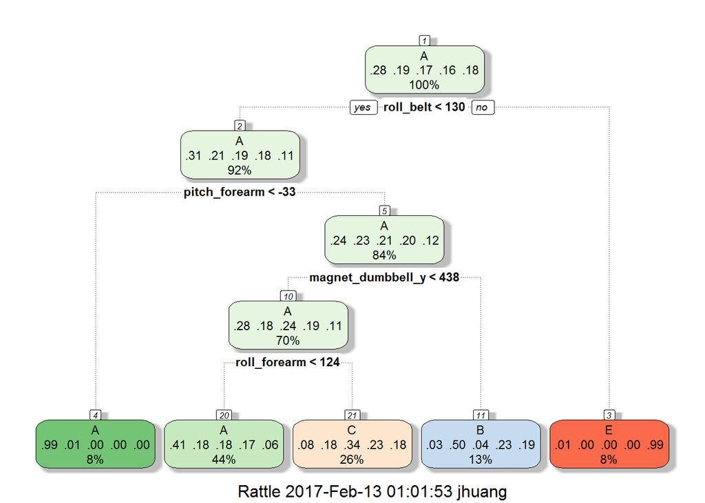

```r
fancyRpartPlot(treeFit$finalModel)
```

```r
treePred <- predict(treeFit,newdata=testing)
confusionMatrix(testing$classe, treePred)
```

```
## Confusion Matrix and Statistics
##
##           Reference
## Prediction    A    B    C    D    E
##          A 1265   27  100    0    3
##          B  399  311  239    0    0
##          C  397   37  421    0    0
##          D  375  122  307    0    0
##          E  134  114  256    0  397
##
## Overall Statistics
##
##                Accuracy : 0.4882
##                  95% CI : (0.4741, 0.5023)
##     No Information Rate : 0.5241
##     P-Value [Acc > NIR] : 1
##
##                   Kappa : 0.3308
##  Mcnemar's Test P-Value : NA
##
## Statistics by Class:
##
##                      Class: A Class: B Class: C Class: D Class: E
## Sensitivity            0.4922  0.50900  0.31822       NA  0.99250
## Specificity            0.9443  0.85139  0.87880   0.8361  0.88810
## Pos Pred Value         0.9068  0.32771  0.49240       NA  0.44062
## Neg Pred Value         0.6281  0.92415  0.77723       NA  0.99925
## Prevalence             0.5241  0.12459  0.26978   0.0000  0.08157
## Detection Rate         0.2580  0.06342  0.08585   0.0000  0.08095
## Detection Prevalence   0.2845  0.19352  0.17435   0.1639  0.18373
## Balanced Accuracy      0.7183  0.68019  0.59851       NA  0.94030
```

### Random Forest

```r
rfFit <-train(classe~.,data=training, method="rf", trControl=trainControl(method="cv", number=3), verbose=FALSE)
rfFit
```

```
## Random Forest
##
## 14718 samples
##    53 predictor
##     5 classes: 'A', 'B', 'C', 'D', 'E'
##
## No pre-processing
## Resampling: Cross-Validated (3 fold)
## Summary of sample sizes: 9813, 9812, 9811
## Resampling results across tuning parameters:
##
##   mtry  Accuracy   Kappa
##    2    0.9924581  0.9904591
##   27    0.9963989  0.9954447
##   53    0.9921185  0.9900304
##
## Accuracy was used to select the optimal model using  the largest value.
## The final value used for the model was mtry = 27.
```

```r
rfPred <- predict(rfFit,testing)
confusionMatrix(testing$classe, rfPred)
```

```
## Confusion Matrix and Statistics
##
##           Reference
## Prediction    A    B    C    D    E
##          A 1393    1    0    0    1
##          B    2  947    0    0    0
##          C    0    4  851    0    0
##          D    0    0    0  804    0
##          E    0    0    0    0  901
##
## Overall Statistics
##
##                Accuracy : 0.9984
##                  95% CI : (0.9968, 0.9993)
##     No Information Rate : 0.2845
##     P-Value [Acc > NIR] : < 2.2e-16
##
##                   Kappa : 0.9979
##  Mcnemar's Test P-Value : NA
##
## Statistics by Class:
##
##                      Class: A Class: B Class: C Class: D Class: E
## Sensitivity            0.9986   0.9947   1.0000   1.0000   0.9989
## Specificity            0.9994   0.9995   0.9990   1.0000   1.0000
## Pos Pred Value         0.9986   0.9979   0.9953   1.0000   1.0000
## Neg Pred Value         0.9994   0.9987   1.0000   1.0000   0.9998
## Prevalence             0.2845   0.1941   0.1735   0.1639   0.1839
## Detection Rate         0.2841   0.1931   0.1735   0.1639   0.1837
## Detection Prevalence   0.2845   0.1935   0.1743   0.1639   0.1837
## Balanced Accuracy      0.9990   0.9971   0.9995   1.0000   0.9994
```

From the confusion matrix shown above, the model built from random forest uses 27 variables and has an accuracy of 0.9984, while the model from decision tree shows an accuracy of 0.4882. Therefore, the random forest model should be used in predict the original test data set.

## Predicting Test Set

```r
predict(rfFit,pml_testing)
```

```
##  [1] B A B A A E D B A A B C B A E E A B B B
## Levels: A B C D E
```